# COLORADO FIRST JUDICIAL RECOVERY COURT SEMI-ANNUAL EVALUATION

# INTRODUCTION

From September 29, 2024 through March 31, 2025, the FJRC enrolled 32 new participants, exceeding the target number of intakes for the grant reporting period. This semi-annual evaluation report provides an overview of participant characteristics at intake drawn from the Government Performance and Results Act (GPRA) Client Outcome Measures for Discretionary Programs Client Outcomes Tool.

# RESULTS

This section provides a description of the 32 FJRC participants, including general demographic information, education, and income. Other information summarized includes past 30-day substances used, living situation, employment, and health.

## Participant Characteristics

### Demographics

The average participant age was 36 years, ranging from 20 to 54 years of age. This reflects a mix of younger and middle-aged adults, consistent with the FJRC target population.

Most participants (19) were male (59%).

Participants were asked to identify their race(s) and ethnicity. They could check multiple categories. The majority of participants (29) identified their race as white (91%). Over one-third (11) identified their ethnicity as Hispanic/Latino/a or of Spanish origin. Other races/ethnicities noted were Mexican (7) , Black (2), Cuban (1), and Other (1).

Participants were asked if they speak a language other than English at home. 9% (3) indicated they did, and 3 indicated this was Spanish.

Respondents were asked how long it takes them to travel to the place they receive treatment. In this case, to court. Nearly half of participants (14) reported having to travel at least an hour or more which may present challenges for attendance.

### Participant Substance Use (SU) and Treatment

Participants were asked which of a list of **substances they used in the past 30 days** and on how many of those days they used the substance(s).

78% of participants (25) reported using substances in the past 30 days. The most commonly used were Nicotine (n =16, average of 28 days the past month) and Tobacco (n =11, average use of 26 days in the past month).

5 participants noted using fentanyl (n = 2, average of 4 days in the past month) and methamphetamine (n = 3, average of 1 day in the past month).

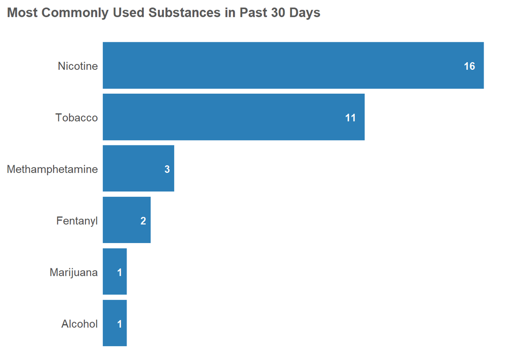

Participants were asked which of four SU disorders they have been diagnosed with, and which if any treatment they received for the disorder(s).

- Alcohol Use Disorder (0)
- Opioid Use Disorder (0)
- Stimulant Use Disorder (1)
- Tobacco Use Disorder (0)

The majority of participants reported having engaged in substance use treatment previously, with 69% (22) reporting three or more treatment episodes. Nearly a quarter (7) indicated they received treatment six or more times.

8 participants received Medically-assisted treatment (MAT) or medications for any type of substance use disorder in the past 30 days, with the most common being Methadone.

- Methadone (MOUD) (5)
- Buprenorphine (MOUD) (2)
- Naltextrone (AUD) (1)

Participants were asked a series of questions related to their mental health. 21 (66%) said they had been diagnosed with a mental health illness by a health care professional. Some shared their diagnosis. The most frequently reported were Post Traumatic Stress Disorder (57%) , Generalized Anxiety Disorder (52%), and Recurrent Major Depressive Disorder (48%)

| Diagnosis | n | % |
| --- | --- | --- |
| PTSD | 12 | 57.1 |
| GAD | 11 | 52.4 |
| Recurrent Major Depressive Disorder | 10 | 47.6 |
| Disorder of Adult Personality and Behavior | 9 | 42.9 |
| Bipolar Disorder | 7 | 33.3 |
| Single Episode Depressive Disorder | 4 | 19.0 |

Participants also shared if they were screened for co-occurring mental health and/or substance use disorders and if they screened positive . All 32 participants were screened by the FJRC for co-occurring disorders and 20 (63%) screened positive.

### Living Situation

Most participants were housed at the time of intake (78%). 16% lived in an institution (i.e., jail). Among those housed, the most common living arrangements included Recovery Residence/Sober Living (56%) and someone else’s home (24%).

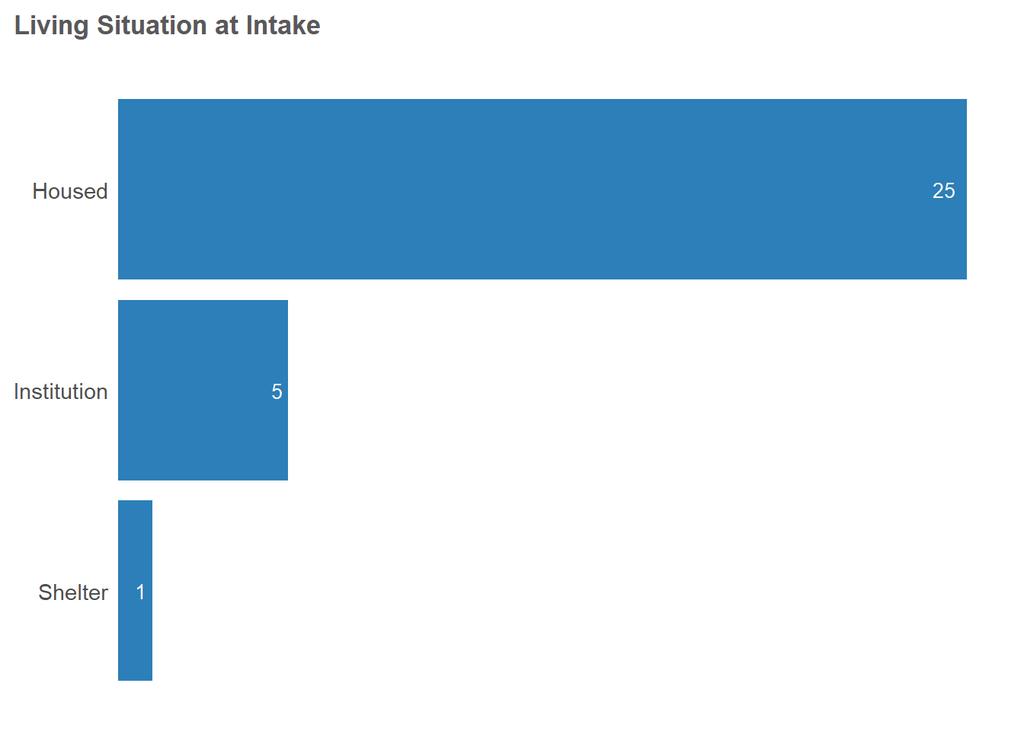

### Education

The GPRA asks participants about level of educational attainment. Over half (17) had at least a high school diploma. Of others, 7 had less than 12th grade and 7 had some college or a degree.

### Employment

Employment remains a challenge, with 69% (22) not looking for work or unemployed and looking for work.

### Income and Expenses

75% of respondents (24) reported their income level as $0-9,999 per year, with the rest making $10,000 or above.

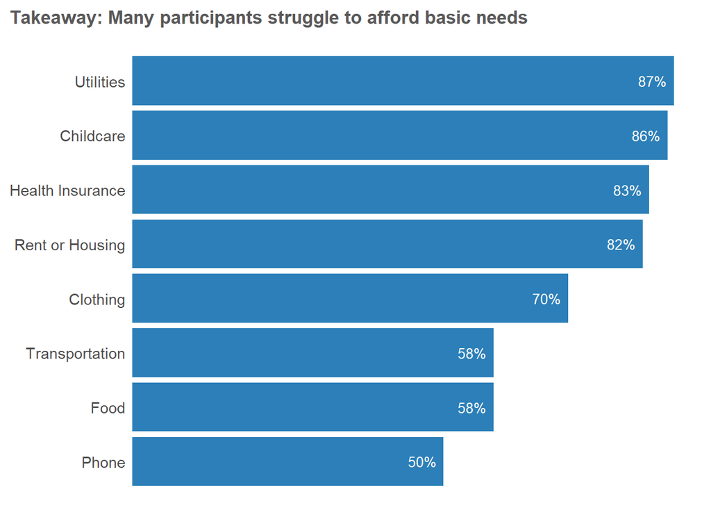

### Quality of Life and Current Mental Health

Participants answered a variety of questions about their physical and mental health. While two-thirds (21) rated their overall quality of life as “good” or “very good,” many also reported experiencing mental health symptoms in the past 30 days. Anxiety (66%) and depression (50%) were the most frequently reported.

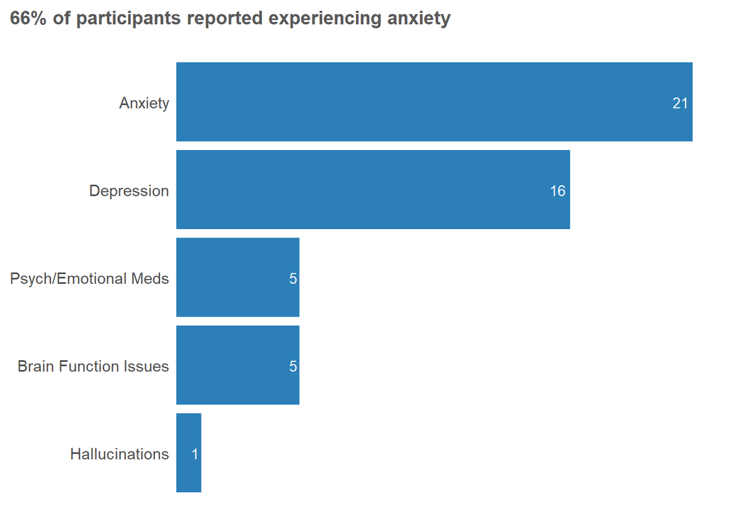

### Social Connections and Relationship Satisfaction

The final section of the GPRA interview asks various questions about social relationships and activities of participants, and their satisfaction with personal relationships. Most participants reported supportive social interactions and an awareness of the need to change connections that may negatively impact recovery.

- 68% (21) reported attending voluntary mutual support groups for recovery
- 77% (24) realized that they need to change those social connections or places that negatively impact recovery
- 97% (30) reported having interactions with family and/or friends that are supportive of recovery

Regarding satisfaction with personal relationships, 75% (24) were satisfied or very satisfied with their personal relationships, which can be a protective factor in recovery

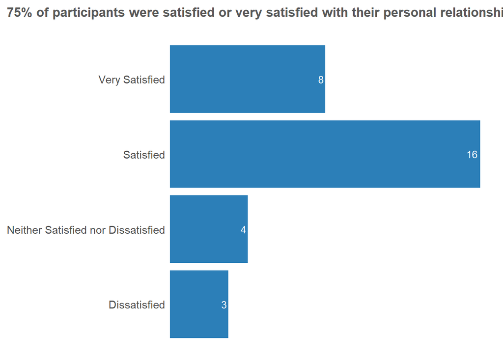